## 1. 간편결제 사용자 구분

#### 기준: 간편결제사용액 4달치

- 4달 전 간편결제 사용자는 최근 이용자가 아니므로 분석에서 제외되어도 큰 문제가 되지 않는다고 보았습니다.
- 해석의 용이성을 위해 결제취소액인 LT02제외하고 결제액인 LT01만 사용
- 먼저 간편결제 사용액을 기준으로 금액이 0이상인 user와 0인 nonuser를 분류했습니다. 그 후 user 사이에서도 유사한 간편결제금액을 사용한 그룹끼리 나누기 위해 군집분석을 실시했습니다.

#### 방법: K-Medoids clustering

- k-medoid Algorism (k-중앙자 알고리즘)

클러스터링은 데이터 객체 집합을 유사성과 비슷한 정도에 따라 다수의 그룹으로 쪼개는 작업을 말합니다. 유사성과 비슷한 정도는 대상을 정의하는 속성 값을 통해 계산하며 주로 거리 측정법을 사용합니다. 흔히 사용하는 클러스터링 기법인 k-means는 평균값을 구하는 연산을 수행하기 때문에 잡음이나 이상치(아웃라이어)에 민감합니다. 저희 팀은 이러한 단점을 해결하기 위해 k-medoids 알고리즘을 사용했습니다. 클러스터의 대표값으로 오브젝트의 중심점을 구하는 k-means와 달리, k-medoids는 실제 오브젝트 중에서 클러스터를 대표할 수 있는 대표 오브젝트를 뽑습니다. 대표로 뽑히지 않은 나머지 오브젝트는 가장 가까운 대표 오브젝트를 따라 해당 클러스터에 배정됩니다. 그후 임의적으로 비대표 객체를 선택하여 대표객체와 비대표객체를 교환하였을 때 발생하는 총비용을 계산합니다. 만약 총비용이 0보다 작다면 이 둘을 바꿔 새로운 k 대표객체의 집합을 형성합니다. 이 과정을 대표객체와 비대표객체가 더 이상 바뀌지 않을 때까지 반복합니다. 이처럼 k-means의 경우 평균을 대표값으로 가져가기 때문에 분산을 기준으로 알고리즘이 진행되는것에 반해 k-medoid는 중앙값을 대표값으로 가져가므로 절대오차를 기준으로 알고리즘이 진행됩니다. 저희는 k-medoid 알고리즘을 가장 일반적으로 실현화한 것중 대표적인 PAM(Partitoning Around Medoid) 알고리즘을 사용하였습니다. 사후적검증방법인 실루엣(silhouette)기법을 통해 자동으로 최적의 군집개수인 k를 찾아주는 KPAM을 사용해 간편결제 lightuser, heavyuser 2개의 군집으로 나누었습니다.

#### 5060 그룹핑 결과:

- 군집0: nonuser, 군집1: lightuser, 군집2: heavyuser

```r
#Sys.getlocale()

#preparing data
#library(caret)
library(tidyverse)
```

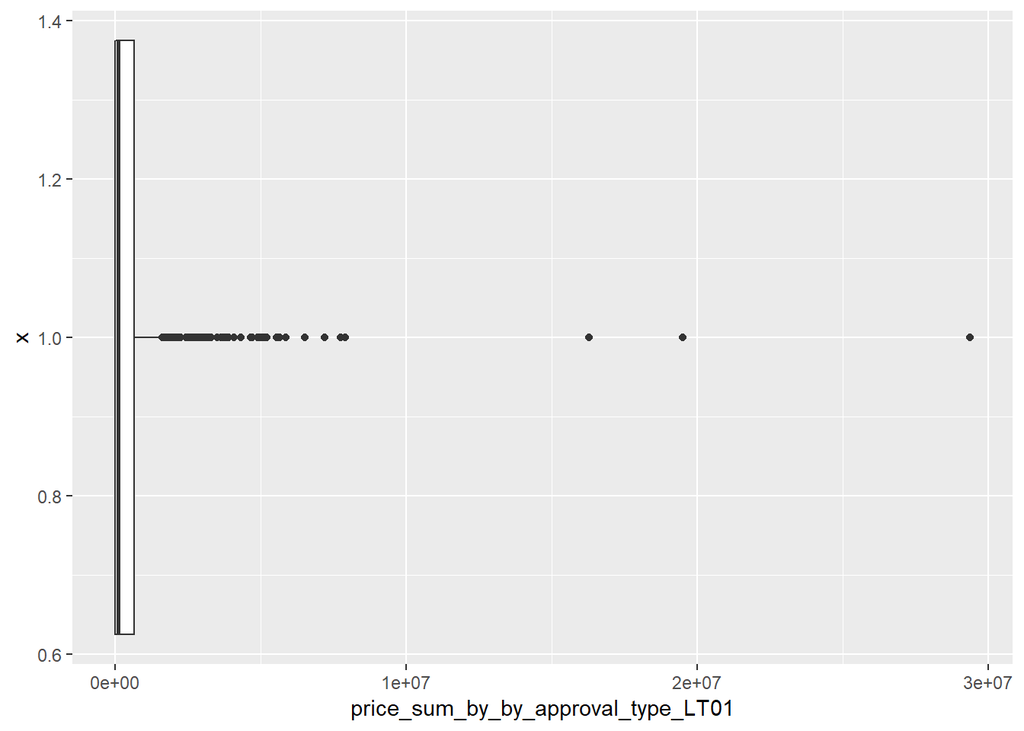

```r
data<-read.csv("C:/Users/JunghaYun/desaip/deguri_new/deguri/analysis/data/payments_ppdb_app_category_code_aggregated_x_cp949.csv", encoding = "CP949")
#data<-read.csv("C:/Users/JunghaYun/Desktop/최종데이터/5060data.csv", encoding="CP949")

data<-data %>% filter(age>=50)

nonuser<-data %>% filter(price_sum_by_by_approval_type_LT01==0)
user<-data %>% filter(price_sum_by_by_approval_type_LT01>0)

#EDA to see outliers
#boxplot
user %>% ggplot(aes(x=1,y=price_sum_by_by_approval_type_LT01))+ geom_boxplot()+coord_flip()
```

```r
# => 3개의 매우 큰 이상치가 있음을 알 수 있다. -> k-means clustering대신 k-medoids기법 사용

# nonuser<-data %>% filter(approval_type_LT01_count==0)
# user<-data %>% filter(approval_type_LT01_count>0)
#   #nrow(user): 501

#필요패키지 다운
#install.packages(c("cluster", "factoextra"))
#install.packages("fpc")
library(cluster)
library(factoextra)
library(fpc)

#K-Medoids clustering (알아서 k개 정해줌, 결과적으로, heavy, light 두 카테고리로 나뉨)
st<-scale(user$price_sum_by_by_approval_type_LT01)
pamk(st)
```

```
## $pamobject
## Medoids:
##       ID
## [1,] 283 -0.3367938
## [2,] 483  0.9393508
## Clustering vector:
##   [1] 1 2 2 1 1 2 1 2 1 1 1 2 1 2 1 2 1 1 1 1 2 1 1 1 1 1 2 2 2 1 1 1 1 1 1
##  [36] 1 1 1 1 1 1 1 1 1 1 2 2 1 1 1 1 1 1 1 1 1 1 2 1 1 1 1 1 1 1 2 1 1 2 1
##  [71] 1 1 2 1 1 1 2 1 1 1 1 2 1 1 2 2 2 2 2 2 1 1 1 1 1 2 1 1 1 1 1 1 2 1 1
## [106] 1 2 1 1 1 1 2 1 1 1 2 1 1 2 1 1 1 1 2 1 1 1 2 1 2 2 1 1 1 1 2 1 1 1 1
## [141] 1 1 2 1 2 1 1 1 1 2 2 1 2 1 1 1 1 1 1 2 1 2 1 1 1 1 2 1 1 1 1 1 1 1 1
## [176] 1 1 1 1 1 1 1 2 1 1 2 1 2 2 1 1 1 1 1 1 1 1 1 2 2 2 2 1 1 1 2 2 1 1 1
## [211] 1 1 1 1 1 1 1 1 1 1 1 2 2 1 2 1 1 1 1 2 1 1 1 2 1 1 1 2 1 1 1 1 1 1 2
## [246] 1 1 1 1 1 1 1 1 1 1 2 1 1 1 1 1 1 1 1 1 1 1 1 1 1 1 1 1 1 1 1 1 1 1 1
## [281] 1 1 1 1 1 1 1 1 1 1 1 1 1 1 1 1 1 1 1 1 1 1 1 1 1 1 1 1 1 1 1 1 1 1 1
## [316] 1 1 1 1 1 1 1 1 1 1 1 1 1 1 1 1 1 1 1 1 1 1 1 1 1 1 1 1 1 1 1 1 1 2 1
## [351] 1 1 1 2 1 1 1 1 1 1 1 1 1 1 1 1 1 1 1 1 1 1 1 1 1 2 2 1 1 1 2 1 1 2 1
## [386] 1 2 1 1 1 2 1 1 1 1 1 1 1 1 1 1 1 1 1 1 1 1 1 1 1 1 1 1 1 1 1 1 1 1 1
## [421] 1 1 1 1 1 1 1 1 1 1 1 1 1 1 1 1 1 1 1 1 1 1 1 1 1 1 1 1 1 1 1 1 1 1 1
## [456] 1 1 1 2 2 1 1 1 1 1 1 1 1 1 1 1 1 1 2 1 1 1 1 1 1 1 2 2 1 1 2 1 1 1 1
## [491] 1 1 1 1 1 1 1 1 1 1 1
## Objective function:
##     build      swap
## 0.2207881 0.2193913
##
## Available components:
##  [1] "medoids"    "id.med"     "clustering" "objective"  "isolation"
##  [6] "clusinfo"   "silinfo"    "diss"       "call"       "data"
##
## $nc
## [1] 2
##
## $crit
##  [1] 0.0000000 0.7842347 0.6880849 0.7186472 0.7140199 0.7147300 0.6561422
##  [8] 0.6749208 0.6751251 0.6756531
```

```r
med<-pamk(st)
med_core<-med$pamobject
table(med_core$clustering)
```

```
##
##   1   2
## 425  76
```

```r
#   0   1   2
# 926 425  76

user$cluster<-med_core$cluster


#경계값
user %>% group_by(cluster) %>%
  summarise(min=min(price_sum_by_by_approval_type_LT01),
            max=max(price_sum_by_by_approval_type_LT01))
```

```
## # A tibble: 2 x 3
##   cluster     min      max
##     <int>   <dbl>    <dbl>
## 1       1     100  1361560
## 2       2 1396500 29361270
```

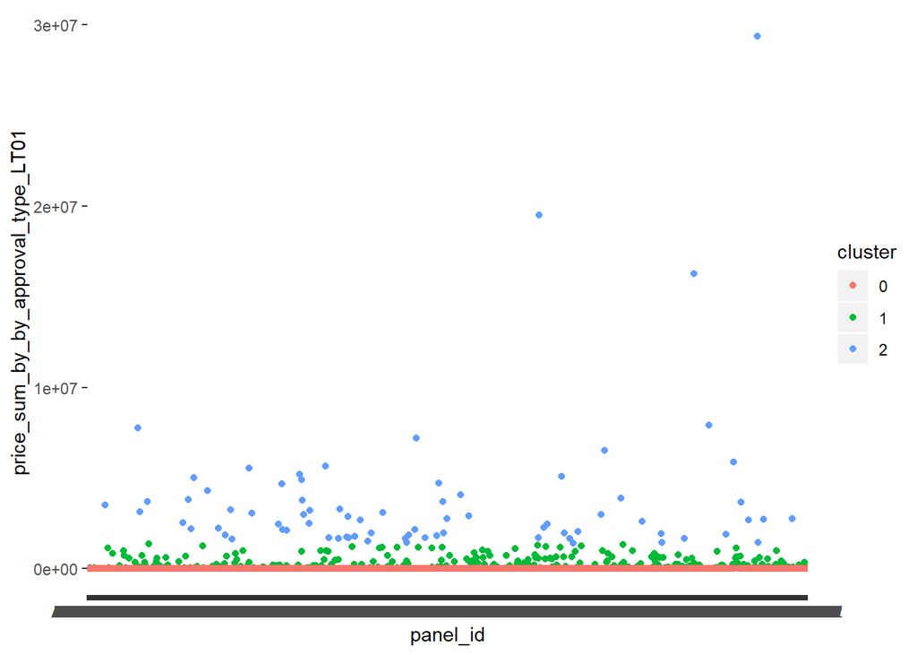

```r
#cluster를 factor에서 숫자로변환
user$cluster<-as.numeric(user$cluster)

# nonuser에 cluster 지정
nonuser$cluster<-0

#dataframe 조인
user.nonuser<-union(user,nonuser)

#시각화
user.nonuser$cluster<-as.factor(user.nonuser$cluster)
user.nonuser %>% ggplot(aes(x=panel_id,y=price_sum_by_by_approval_type_LT01,color=cluster))+geom_point()
```

```r
#경계값
user.nonuser %>% group_by(cluster) %>%
  summarise(min=min(price_sum_by_by_approval_type_LT01),
            max=max(price_sum_by_by_approval_type_LT01))
```

```
## # A tibble: 3 x 3
##   cluster     min      max
##   <fct>     <dbl>    <dbl>
## 1 0             0        0
## 2 1           100  1361560
## 3 2       1396500 29361270
```

```r
#csv 파일로 저장
#write.csv(user.nonuser,file="C:/Users/JunghaYun/desaip/deguri/analysis_by_Yun/5060_3cluster.csv",row.names=FALSE)
```